# Chi-squares

Adam Raikes

March 13, 2017

# Purpose

The purpose of this slideshow is to discuss chi-squares. A chi-square tests whether two categorical variables are independent of one another. Understand that if a dependency does exist, there isn’t necessarily a causal relationship.

# Chi-square

Chi-squares consider a structure much like the contingency tables we saw when we look at the M & M data. The question being address is whether or not there is any structure to the counts of data in the table or whether they are essentially haphazard.

# Chi-square distribution

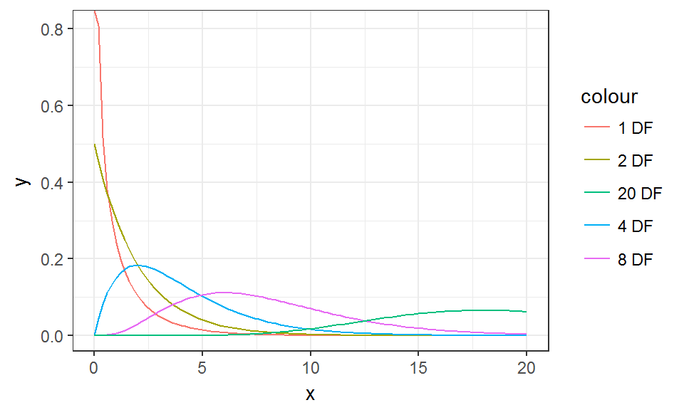

# Chi-square

When working with chi-squares, there are assumptions that must be met.

# Chi-square

Recall that we must set our null and alternative hypothesis.

$H_0:$ The two categorical variables are independent.

$H_A:$ The two categorical variables are not independent.

# Chi-square

How do we compute a chi-square?

$\chi^2 = \sum\limits_{cells}{}\frac{(Observed\; -\; Expected)^2}{Expected}$

where

$Expected = \frac{Row\; Total\; x\; Column\; Total}{Table\; Total}$

# How does this look

Let’s look at the class M & M data

```
##
##
##    Cell Contents
## |-------------------------|
## |                       N |
## | Chi-square contribution |
## |           N / Row Total |
## |           N / Col Total |
## |         N / Table Total |
## |-------------------------|
##
##
## Total Observations in Table:  711
##
##
##              | mnm$Defect
##    mnm$Color |         C |         L |         M |         N | Row Total |
## -------------|-----------|-----------|-----------|-----------|-----------|
##         Blue |         0 |        19 |         2 |        56 |        77 |
##              |     1.949 |     0.938 |     0.097 |     1.049 |           |
##              |     0.000 |     0.247 |     0.026 |     0.727 |     0.108 |
##              |     0.000 |     0.087 |     0.087 |     0.124 |           |
##              |     0.000 |     0.027 |     0.003 |     0.079 |           |
## -------------|-----------|-----------|-----------|-----------|-----------|
##        Brown |         2 |        36 |         0 |        70 |       108 |
##              |     0.197 |     0.225 |     3.494 |     0.033 |           |
##              |     0.019 |     0.333 |     0.000 |     0.648 |     0.152 |
##              |     0.111 |     0.164 |     0.000 |     0.155 |           |
##              |     0.003 |     0.051 |     0.000 |     0.098 |           |
## -------------|-----------|-----------|-----------|-----------|-----------|
##        Green |         5 |        50 |         6 |        79 |       140 |
##              |     0.598 |     1.097 |     0.478 |     1.082 |           |
##              |     0.036 |     0.357 |     0.043 |     0.564 |     0.197 |
##              |     0.278 |     0.228 |     0.261 |     0.175 |           |
##              |     0.007 |     0.070 |     0.008 |     0.111 |           |
## -------------|-----------|-----------|-----------|-----------|-----------|
##       Orange |         2 |        43 |         8 |       100 |       153 |
##              |     0.906 |     0.361 |     1.880 |     0.090 |           |
##              |     0.013 |     0.281 |     0.052 |     0.654 |     0.215 |
##              |     0.111 |     0.196 |     0.348 |     0.222 |           |
##              |     0.003 |     0.060 |     0.011 |     0.141 |           |
## -------------|-----------|-----------|-----------|-----------|-----------|
##          Red |         7 |        37 |         4 |        67 |       115 |
##              |     5.742 |     0.070 |     0.021 |     0.485 |           |
##              |     0.061 |     0.322 |     0.035 |     0.583 |     0.162 |
##              |     0.389 |     0.169 |     0.174 |     0.149 |           |
##              |     0.010 |     0.052 |     0.006 |     0.094 |           |
## -------------|-----------|-----------|-----------|-----------|-----------|
##       Yellow |         2 |        34 |         3 |        79 |       118 |
##              |     0.326 |     0.151 |     0.175 |     0.230 |           |
##              |     0.017 |     0.288 |     0.025 |     0.669 |     0.166 |
##              |     0.111 |     0.155 |     0.130 |     0.175 |           |
##              |     0.003 |     0.048 |     0.004 |     0.111 |           |
## -------------|-----------|-----------|-----------|-----------|-----------|
## Column Total |        18 |       219 |        23 |       451 |       711 |
##              |     0.025 |     0.308 |     0.032 |     0.634 |           |
## -------------|-----------|-----------|-----------|-----------|-----------|
##
##
```

# Chi-square

So what do we want to know?

```r
chisq.test(mnm$Color, mnm$Defect)
```

```
##
##  Pearson's Chi-squared test
##
## data:  mnm$Color and mnm$Defect
## X-squared = 21.675, df = 15, p-value = 0.1166
```

# Chi-square

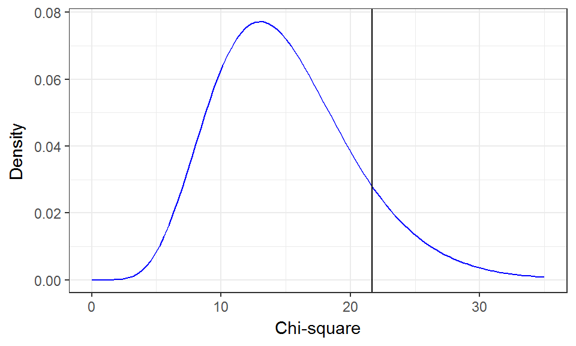

# How about some class data?

Is marital status independent of gender?

```r
CrossTable(class.data$Gender, class.data$Married)
```

```
##
##
##    Cell Contents
## |-------------------------|
## |                       N |
## | Chi-square contribution |
## |           N / Row Total |
## |           N / Col Total |
## |         N / Table Total |
## |-------------------------|
##
##
## Total Observations in Table:  49
##
##
##                   | class.data$Married
## class.data$Gender |        No |       Yes | Row Total |
## ------------------|-----------|-----------|-----------|
##            Female |        27 |         3 |        30 |
##                   |     0.257 |     1.144 |           |
##                   |     0.900 |     0.100 |     0.612 |
##                   |     0.675 |     0.333 |           |
##                   |     0.551 |     0.061 |           |
## ------------------|-----------|-----------|-----------|
##              Male |        13 |         6 |        19 |
##                   |     0.406 |     1.806 |           |
##                   |     0.684 |     0.316 |     0.388 |
##                   |     0.325 |     0.667 |           |
##                   |     0.265 |     0.122 |           |
## ------------------|-----------|-----------|-----------|
##      Column Total |        40 |         9 |        49 |
##                   |     0.816 |     0.184 |           |
## ------------------|-----------|-----------|-----------|
##
##
```

# How about some class data?

Is marital status independent of gender?

```r
married.chi <- chisq.test(class.data$Gender, class.data$Married)
married.chi
```

```
##
##  Pearson's Chi-squared test with Yates' continuity correction
##
## data:  class.data$Gender and class.data$Married
## X-squared = 2.3168, df = 1, p-value = 0.128
```

# What are our expected values?

Is marital status independent of gender?

```r
married.chi$expected
```

```
##                  class.data$Married
## class.data$Gender      No      Yes
##            Female 24.4898 5.510204
##            Male   15.5102 3.489796
```

# What about the error?

One of our cells is *too small* (though perhaps not). We can compute Fisher’s exact test when this is the case.

```r
fisher.test(class.data$Gender, class.data$Married)
```

```
##
##  Fisher's Exact Test for Count Data
##
## data:  class.data$Gender and class.data$Married
## p-value = 0.0724
## alternative hypothesis: true odds ratio is not equal to 1
## 95 percent confidence interval:
##   0.7227821 28.9014264
## sample estimates:
## odds ratio
##   4.024465
```

# Anything else?

What about gender and politics?

```r
CrossTable(class.data$Gender, class.data$Politics)
```

```
##
##
##    Cell Contents
## |-------------------------|
## |                       N |
## | Chi-square contribution |
## |           N / Row Total |
## |           N / Col Total |
## |         N / Table Total |
## |-------------------------|
##
##
## Total Observations in Table:  49
##
##
##                   | class.data$Politics
## class.data$Gender |  Democratic | Independent | Libertarian |         N/A |  Republican |   Row Total |
## ------------------|-------------|-------------|-------------|-------------|-------------|-------------|
##            Female |           2 |           2 |           0 |          12 |          14 |          30 |
##                   |       0.491 |       0.082 |       0.612 |       0.012 |       0.000 |             |
##                   |       0.067 |       0.067 |       0.000 |       0.400 |       0.467 |       0.612 |
##                   |       1.000 |       0.500 |       0.000 |       0.632 |       0.609 |             |
##                   |       0.041 |       0.041 |       0.000 |       0.245 |       0.286 |             |
## ------------------|-------------|-------------|-------------|-------------|-------------|-------------|
##              Male |           0 |           2 |           1 |           7 |           9 |          19 |
##                   |       0.776 |       0.130 |       0.967 |       0.018 |       0.001 |             |
##                   |       0.000 |       0.105 |       0.053 |       0.368 |       0.474 |       0.388 |
##                   |       0.000 |       0.500 |       1.000 |       0.368 |       0.391 |             |
##                   |       0.000 |       0.041 |       0.020 |       0.143 |       0.184 |             |
## ------------------|-------------|-------------|-------------|-------------|-------------|-------------|
##      Column Total |           2 |           4 |           1 |          19 |          23 |          49 |
##                   |       0.041 |       0.082 |       0.020 |       0.388 |       0.469 |             |
## ------------------|-------------|-------------|-------------|-------------|-------------|-------------|
##
##
```

# Anything else?

What about gender and politics?

```r
chisq.test(class.data$Gender, class.data$Politics)
```

```
##
##  Pearson's Chi-squared test
##
## data:  class.data$Gender and class.data$Politics
## X-squared = 3.089, df = 4, p-value = 0.543
```

```r
fisher.test(class.data$Gender, class.data$Politics)
```

```
##
##  Fisher's Exact Test for Count Data
##
## data:  class.data$Gender and class.data$Politics
## p-value = 0.6531
## alternative hypothesis: two.sided
```